# Análisis Geoespacial para la Conservación

Práctica: Riesgo de inundación en Puerto Vallarta

# Objetivo

Desarrollar un análisis espacial para mapear el riesgo de inundación en una cuenca hidrográfica, integrando variables clave como elevación, pendiente, uso del suelo, edafología, precipitación y distancia a escurrimientos.

# Descripción

En esta práctica se emplearán herramientas de procesamiento geográfico en R, incluyendo recorte, la reclasificación de capas, creación de áreas de influencia, álgebra de mapas, generación de mapas temáticos y cálculo de áreas de riesgo, con el fin de identificar zonas vulnerables y facilitar la toma de decisiones en la gestión del territorio.

# Datos

| Datos | Unidades | Descripción |
| --- | --- | --- |
| Elevación (DEM) | Metros (m) | Áreas bajas acumulan más agua, aumentando el riesgo de inundación. |
| Pendiente | Grados (°) | Pendientes bajas acumulan agua; pendientes altas facilitan el drenaje. |
| Uso del suelo | Categorías | Áreas urbanas y agrícolas tienen mayor riesgo por impermeabilización. |
| Edafología | Tipos de suelo | Suelos poco permeables son más propensos a saturarse y generar escorrentías. |
| Precipitación | Milímetros (mm) | Cantidad de lluvia que puede generar escorrentías significativas. |
| Distancia a escurrimientos | Metros (m) | Áreas cercanas a cuerpos de agua tienen mayor riesgo de inundación. |

Descarga los datos [aquí](https://drive.google.com/file/d/1ERbLbfVcqedmc3q2g3NxLolCtGcTbyGK/view?usp=sharing).

# Pasos generales

1. Instalar y cargar librerías necesarias.
2. Establecer directorio de los datos.
3. Cargar las capas de datos geográficos.
4. Estandarizar las capas recortándolas con el polígono de la cuenca.
5. Filtrar atributos de los archivos vectoriales.
6. Mapear las capas de datos geográficos originales.
7. Reclasificar las capas de insumo según criterios de riesgo.
8. Rasterizar las capas vectoriales reclasificadas.
9. Mapear las capas reclasificadas individualmente.
10. Crear y mapear la capa de riesgo final combinando todas las capas reclasificadas.
11. Realizar cálculos de área por nivel de riesgo y exportar los resultados.
12. Bono extra: Inspeccionar el mapa de riesgo final de forma interactiva con Leaflet.

# Instrucciones

Antes de comenzar, crear un directorio de trabajo en una carpeta en la que se tengan derechos de escritura. El directorio debe tener las siguientes subcarpetas:

- CODIGO
- DATOS
- RESULTADO
- FIGURAS

A continuación, copiar, pegar y ejectutar en un script de R cada bloque de código.

Instalar y cargar librerías necesarias: Se instalan y cargan las librerías requeridas para el análisis espacial, como `sf`, `terra`, `dplyr` y `ggplot2`.

```r
# Paso 1: Instalar y cargar librerías necesarias
# install.packages("sf")
# install.packages("terra")
# install.packages("dplyr")
# install.packages("ggplot2")

library(sf)
library(terra)
library(dplyr)
library(ggplot2)
```

Establecer directorio de los datos: Se definen las rutas de las carpetas donde se encuentran los datos de entrada y donde se guardarán los resultados. **Nota**: observa cuidadosamente el formato de los directorios, reemplaza las rutas con las rutas de los directorios en tu computadora.

```r
# Paso 2: Establecer directorio de los datos
input_folder <- "C:/Users/JPG/Documents/GEOSPATIAL-PRACTICAS-2026A/RIESGO_INUNDACION/DATOS/"
output_folder <- "C:/Users/JPG/Documents/GEOSPATIAL-PRACTICAS-2026A/RIESGO_INUNDACION/RESULTADOS/"
```

Cargar las capas de datos geográficos: Se importan las capas raster y vectoriales necesarias para el análisis, como DEM, uso del suelo, edafología, precipitación, cuenca y escurrimientos.

```r
# Paso 3: Cargar las capas de datos
dem      <- rast(paste0(input_folder, "dem_utm.tif"))
uso_sue  <- st_read(paste0(input_folder, "uso_suelo_utm.shp"), quiet = TRUE)
edafolog <- st_read(paste0(input_folder, "edafologia_utm.shp"), quiet = TRUE)
precipit <- st_read(paste0(input_folder, "precipitacion_utm.shp"), quiet = TRUE)
cuenca   <- st_read(paste0(input_folder, "cuenca_utm.shp"), quiet = TRUE)
escurrim <- st_read(paste0(input_folder, "escurrimientos_utm.shp"), quiet = TRUE)
```

Estandarizar las capas: Se recortan las capas geográficas al área de la cuenca para limitar el análisis al área de interés. Adicionalmente, se genera la capa pendiente del terreno.

```r
# Paso 4: Estandarizar las capas: recortar con el polígono de la cuenca
dem_cuenca           <- crop(dem, vect(cuenca), mask = TRUE)
uso_suelo_cuenca     <- st_intersection(uso_sue, cuenca)
edafologia_cuenca    <- st_intersection(edafolog, cuenca)
precipitacion_cuenca <- st_intersection(precipit, cuenca)
escurrimientos_cuenca<- st_intersection(escurrim, cuenca)
# Crear variable "pendiente"
pendiente<- terrain(dem_cuenca,v="slope",unit="degrees")
```

Filtrar atributos de los archivos vectoriales: Se seleccionan únicamente los atributos relevantes de las capas vectoriales para simplificar el análisis.

```r
# Paso 5: Filtrar atributos de los archivos vectoriales
cuenca <- cuenca %>% select(SUBCUENCA)
uso_suelo_cuenca <- uso_suelo_cuenca %>% select(DESCRIPCIO)
edafologia_cuenca <- edafologia_cuenca %>% select(descripcio)
precipitacion_cuenca <- precipitacion_cuenca %>% select(precipitac)
escurrimientos_cuenca <- escurrimientos_cuenca %>%
  select(ORDER_1) %>%
  filter(ORDER_1 >= 3 & ORDER_1 <= 4)
```

Mapear las capas de datos geográficos originales: Se visualizan las capas originales para explorar su distribución espacial y características.

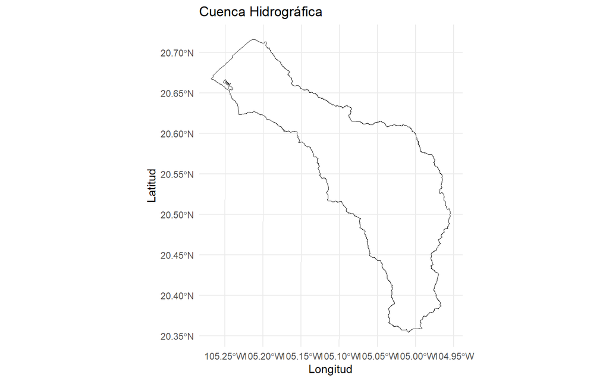

```r
# Paso 6: Mapear capas de datos geográficos
# 1. Polígno de la cuenca (sf)
ggplot() +
  geom_sf(data = cuenca, fill = NA, color = "black", size = 1) +
  labs(title = "Cuenca Hidrográfica", x = "Longitud", y = "Latitud") +
  theme_minimal()
```

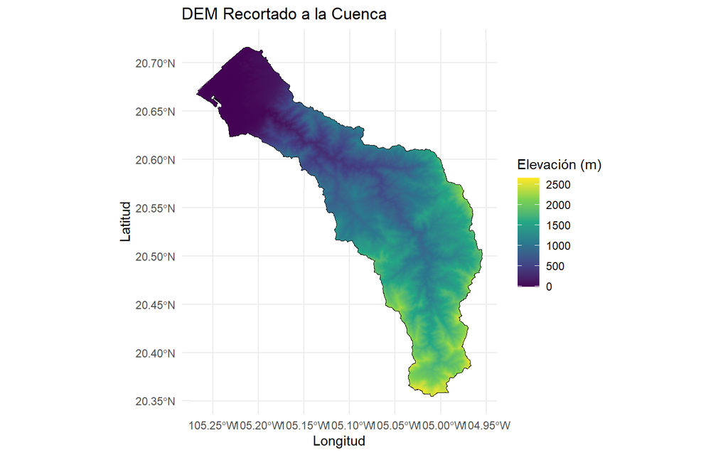

```r
# 2. DEM recortado (RasterLayer)
dem_df <- as.data.frame(dem_cuenca, xy = TRUE)
colnames(dem_df) <- c("x", "y", "value")

ggplot() +
  geom_raster(data = dem_df, aes(x = x, y = y, fill = value)) +
  geom_sf(data = cuenca, fill = NA, color = "black", size = 0.8) +
  scale_fill_viridis_c(name = "Elevación (m)") +
  labs(title = "DEM Recortado a la Cuenca", x = "Longitud", y = "Latitud") +
  theme_minimal()
```

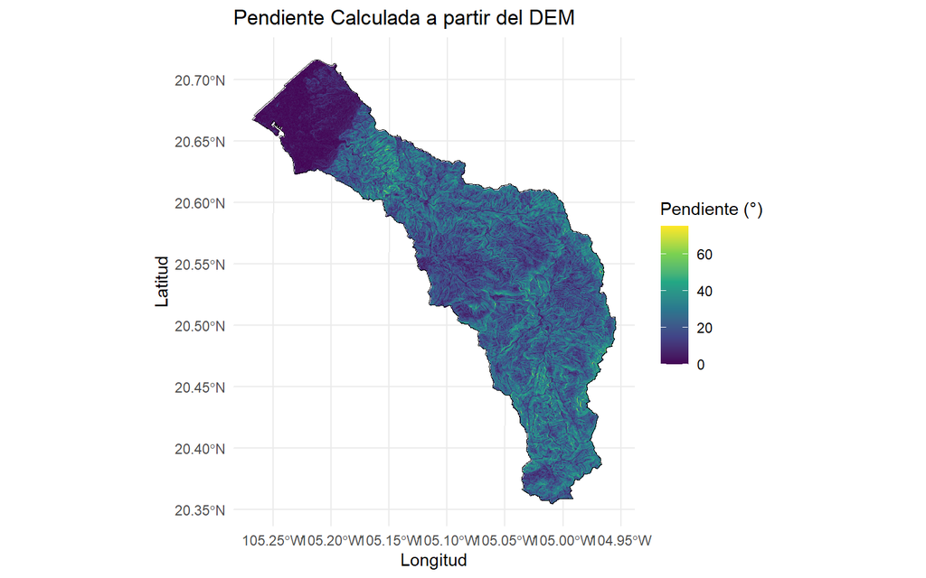

```r
# 3. Pendiente (RasterLayer)
pendiente_df <- as.data.frame(pendiente, xy = TRUE)
colnames(pendiente_df) <- c("x", "y", "value")

ggplot() +
  geom_raster(data = pendiente_df, aes(x = x, y = y, fill = value)) +
  geom_sf(data = cuenca, fill = NA, color = "black", size = 0.8) +
  scale_fill_viridis_c(name = "Pendiente (°)") +
  labs(title = "Pendiente Calculada a partir del DEM", x = "Longitud", y = "Latitud") +
  theme_minimal()
```

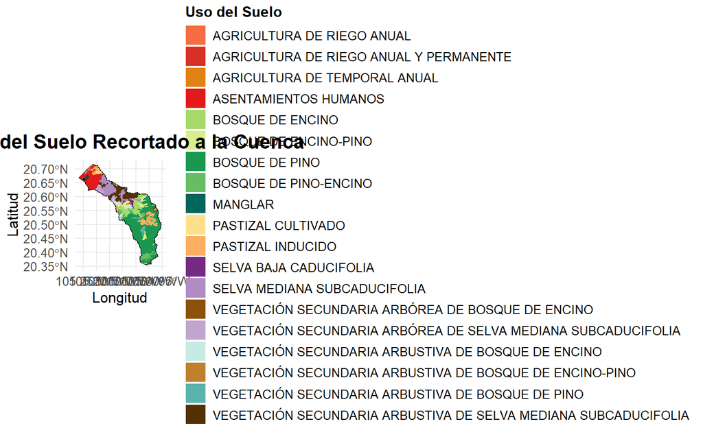

```r
# 4. Uso del suelo recortado (sf)
ggplot() +
  geom_sf(data = uso_suelo_cuenca, aes(fill = DESCRIPCIO), color = NA) +
  geom_sf(data = cuenca, fill = NA, color = "black", size = 0.8) +
  scale_fill_manual(
    name = "Uso del Suelo",
    values = c(
      "ASENTAMIENTOS HUMANOS" = "#e31a1c", # Rojo oscuro
      "BOSQUE DE PINO" = "#1a9850",        # Verde oscuro
      "BOSQUE DE PINO-ENCINO" = "#66bd63", # Verde claro
      "BOSQUE DE ENCINO" = "#a6d96a",      # Verde pálido
      "BOSQUE DE ENCINO-PINO" = "#d9ef8b", # Amarillo verdoso
      "PASTIZAL CULTIVADO" = "#fee08b",    # Amarillo
      "PASTIZAL INDUCIDO" = "#fdae61",     # Naranja
      "AGRICULTURA DE RIEGO ANUAL" = "#f46d43", # Naranja oscuro
      "AGRICULTURA DE RIEGO ANUAL Y PERMANENTE" = "#d73027",  # Rojo
      "SELVA BAJA CADUCIFOLIA" = "#762a83", # Morado oscuro
      "SELVA MEDIANA SUBCADUCIFOLIA" = "#af8dc3", # Morado claro
      "AGRICULTURA DE TEMPORAL ANUAL" = "#e08214", # Naranja tierra
      "MANGLAR" = "#01665e",               # Verde azulado oscuro
      "VEGETACIÓN SECUNDARIA ARBUSTIVA DE BOSQUE DE PINO" = "#5ab4ac", # Verde azulado
      "VEGETACIÓN SECUNDARIA ARBUSTIVA DE BOSQUE DE ENCINO" = "#c7eae5", # Verde azulado claro
      "VEGETACIÓN SECUNDARIA ARBÓREA DE BOSQUE DE ENCINO" = "#8c510a", # Marrón oscuro
      "VEGETACIÓN SECUNDARIA ARBUSTIVA DE BOSQUE DE ENCINO-PINO" = "#bf812d", # Marrón claro
      "VEGETACIÓN SECUNDARIA ARBUSTIVA DE SELVA MEDIANA SUBCADUCIFOLIA" = "#543005", # Marrón muy oscuro
      "VEGETACIÓN SECUNDARIA ARBÓREA DE SELVA MEDIANA SUBCADUCIFOLIA" = "#c2a5cf"  # Lila claro
    )
  ) +
  labs(
    title = "3. Uso del Suelo Recortado a la Cuenca",
    x = "Longitud",
    y = "Latitud"
  ) +
  theme_minimal() +
  theme(
    plot.title = element_text(size = 16, face = "bold", hjust = 0.5),
    axis.title = element_text(size = 12),
    axis.text = element_text(size = 10),
    legend.title = element_text(size = 12, face = "bold"),
    legend.text = element_text(size = 10),
    legend.position = "right"
  )
```

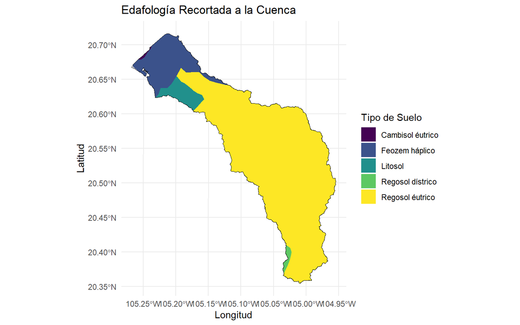

```r
# 5. Edafología recortada (sf)
ggplot() +
  geom_sf(data = edafologia_cuenca, aes(fill = descripcio), color = NA) +
  geom_sf(data = cuenca, fill = NA, color = "black", size = 0.8) +
  scale_fill_viridis_d(name = "Tipo de Suelo") +
  labs(title = "Edafología Recortada a la Cuenca", x = "Longitud", y = "Latitud") +
  theme_minimal()
```

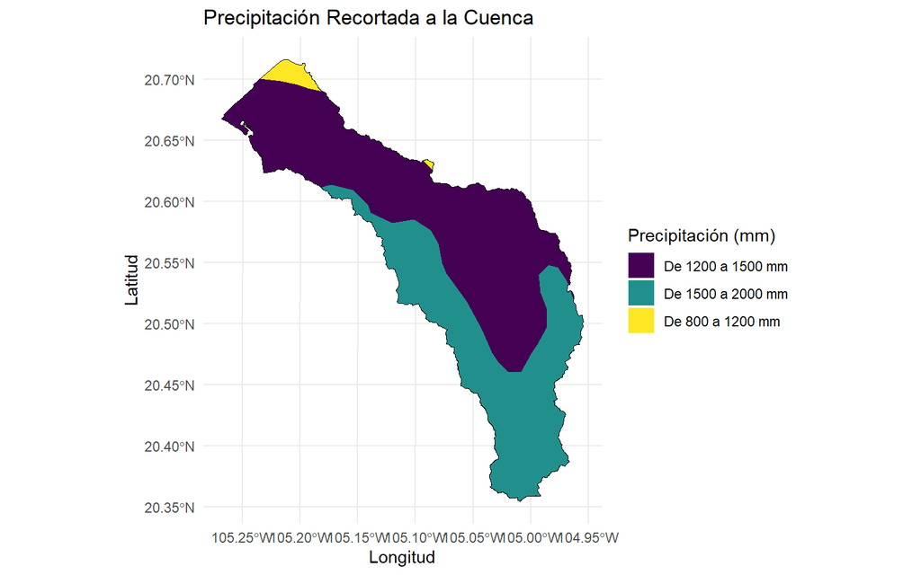

```r
# 6. Precipitación recortada (sf)
ggplot() +
  geom_sf(data = precipitacion_cuenca, aes(fill = precipitac), color = NA) +
  geom_sf(data = cuenca, fill = NA, color = "black", size = 0.8) +
  scale_fill_viridis_d(name = "Precipitación (mm)") +
  labs(title = "Precipitación Recortada a la Cuenca", x = "Longitud", y = "Latitud") +
  theme_minimal()
```

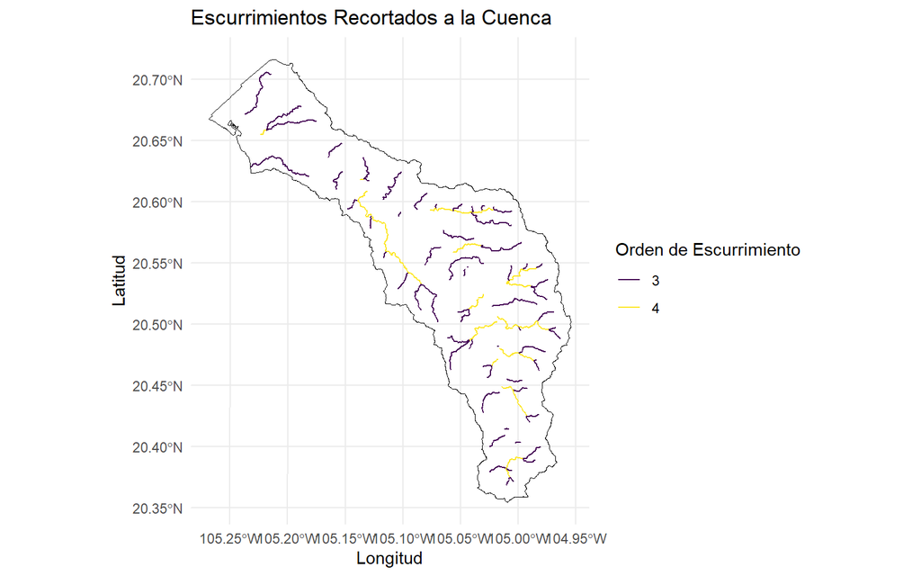

```r
# 7. Escurrimientos recortados (sf)
ggplot() +
  geom_sf(data = escurrimientos_cuenca, aes(color = factor(ORDER_1)), size = 0.8) +
  geom_sf(data = cuenca, fill = NA, color = "black", size = 0.8) +
  scale_color_viridis_d(name = "Orden de Escurrimiento") +
  labs(title = "Escurrimientos Recortados a la Cuenca", x = "Longitud", y = "Latitud") +
  theme_minimal()
```

Reclasificar las capas de insumo: Se asignan valores de riesgo a las capas según criterios específicos, como elevación, pendiente y uso del suelo.

Los criterios se toman de la literatura o de entrevistas con expertos. En esta práctica se emplearán los siguientes rangos de valores para los distintos niveles:

| Variable | Rango | Clase | Descripción |
| --- | --- | --- | --- |
| DEM (Elevación) | 1000 - Inf | 1 | Áreas altas con menor riesgo de inundación |
|  | 10 - 1000 | 2 | Áreas intermedias con riesgo moderado |
|  | -10 - 10 | 3 | Áreas bajas con mayor riesgo de inundación |
| Pendiente | 25 - Inf | 1 | Pendientes altas con menor riesgo de acumulación de agua |
|  | 15 - 25 | 2 | Pendientes moderadas con riesgo intermedio |
|  | 0 - 15 | 3 | Pendientes bajas con mayor riesgo de acumulación de agua |
|  | -Inf - 0 | NA | Valores negativos no considerados |
| Uso del Suelo | Asentamientos Humanos | 3 | Alto riesgo |
|  | Agricultura | 3 | Alto riesgo |
|  | Pastizales | 2 | Riesgo medio |
|  | Vegetación Natural | 1 | Bajo riesgo |
| Edafología | Regosol dístrico | 3 | Suelos con alta susceptibilidad a inundaciones |
|  | Litosol | 3 | Suelos con alta susceptibilidad a inundaciones |
|  | Regosol éutrico | 2 | Suelos con susceptibilidad moderada |
|  | Cambisol éutrico | 2 | Suelos con susceptibilidad moderada |
|  | Otros | 1 | Suelos estables con menor susceptibilidad |
| Precipitación | De 800 a 1200 mm | 1 | Bajo riesgo |
|  | De 1200 a 1500 mm | 2 | Riesgo medio |
|  | De 1500 a 2000 mm | 3 | Alto riesgo |
| Distancia a Escurrimientos | 0 - 100 m | 3 | Alto riesgo |
|  | 100 - 500 m | 2 | Riesgo medio |
|  | > 500 m | 1 | Bajo riesgo |
| Riesgo Final | 0 - 1.5 | 1 | Bajo riesgo |
|  | 1.5 - 2.25 | 2 | Riesgo medio |
|  | 2.25 - 3 | 3 | Alto riesgo |

```r
# Paso 7: Reclasificaciones
# DEM
dem_reclas <- classify(dem_cuenca,
                       rcl = matrix(c(1000, Inf, 1,
                                      10, 1000, 2,
                                      -10, 10, 3),
                                    ncol = 3, byrow = TRUE))

# Pendiente
pendiente_reclas <- classify(pendiente,
                             rcl = matrix(c(25, Inf, 1,
                                            15, 25, 2,
                                            0, 15, 3,
                                            -Inf, 0, NA),
                                          ncol = 3, byrow = TRUE))

# Uso del suelo
uso_suelo_cuenca <- uso_suelo_cuenca %>%
  mutate(riesgo = case_when(
    DESCRIPCIO %in% c("ASENTAMIENTOS HUMANOS",
                      "AGRICULTURA DE RIEGO ANUAL",
                      "AGRICULTURA DE TEMPORAL ANUAL") ~ 3,
    DESCRIPCIO %in% c("PASTIZAL CULTIVADO",
                      "PASTIZAL INDUCIDO") ~ 2,
    TRUE ~ 1
  ))

# Edafología
edafologia_cuenca <- edafologia_cuenca %>%
  mutate(riesgo = case_when(
    descripcio %in% c("Regosol dístrico", "Litosol") ~ 3,
    descripcio %in% c("Regosol éutrico", "Cambisol éutrico") ~ 2,
    TRUE ~ 1
  ))

# Precipitación
precipitacion_cuenca <- precipitacion_cuenca %>%
  mutate(riesgo = case_when(
    precipitac == "De 800 a 1200 mm" ~ 1,
    precipitac == "De 1200 a 1500 mm" ~ 2,
    precipitac == "De 1500 a 2000 mm" ~ 3
  ))

# Distancia a escurrimientos
escurrimientos_raster   <- rasterize(vect(escurrimientos_cuenca), dem_cuenca, field = 1, background = NA)
distancia_escurrimientos<- distance(escurrimientos_raster)
distancia_escurrimientos<- crop(distancia_escurrimientos, vect(cuenca), mask = TRUE)
distancia_reclas        <- classify(distancia_escurrimientos,
                             rcl = matrix(c(-0.01, 100, 3,
                                            100, 500, 2,
                                            500, Inf, 1),
                                          ncol = 3, byrow = TRUE))
```

Rasterizar las capas vectoriales reclasificadas: Se convierten las capas vectoriales reclasificadas a formato raster para integrarlas en el análisis final.

```r
# Paso 8: Rasterizar capas vectoriales reclasificadas
uso_suelo_raster    <- rasterize(vect(uso_suelo_cuenca), dem_cuenca, field = "riesgo", background = NA)
edafologia_raster   <- rasterize(vect(edafologia_cuenca), dem_cuenca, field = "riesgo", background = NA)
precipitacion_raster<- rasterize(vect(precipitacion_cuenca), dem_cuenca, field = "riesgo", background = NA)
```

Mapear las capas reclasificadas individualmente: Se visualizan las capas reclasificadas para verificar los valores asignados y su distribución espacial.

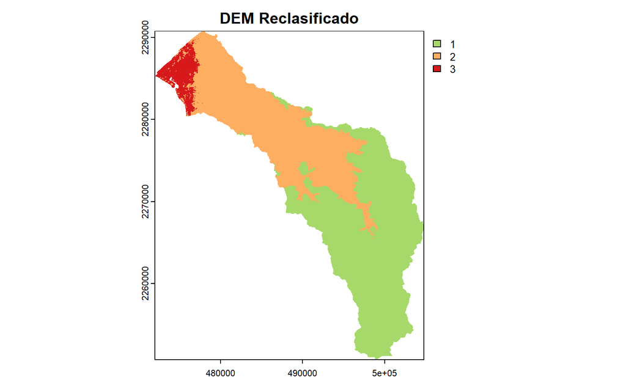

```r
# Paso 9: Mapear capas reclasificadas individualmente
plot(dem_reclas, main = "DEM Reclasificado", col = c("#a6d96a", "#fdae61", "#d7191c"))
```

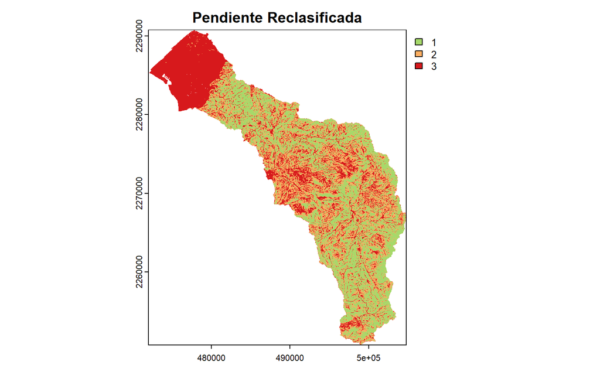

```r
plot(pendiente_reclas, main = "Pendiente Reclasificada", col = c("#a6d96a", "#fdae61", "#d7191c"))
```

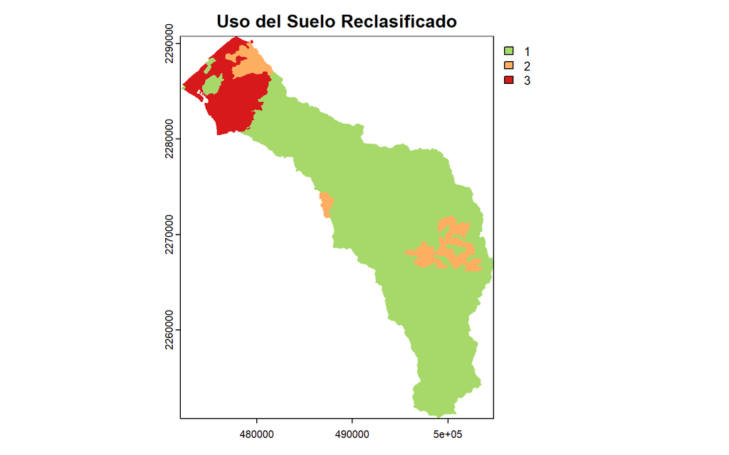

```r
plot(uso_suelo_raster, main = "Uso del Suelo Reclasificado", col = c("#a6d96a", "#fdae61", "#d7191c"))
```

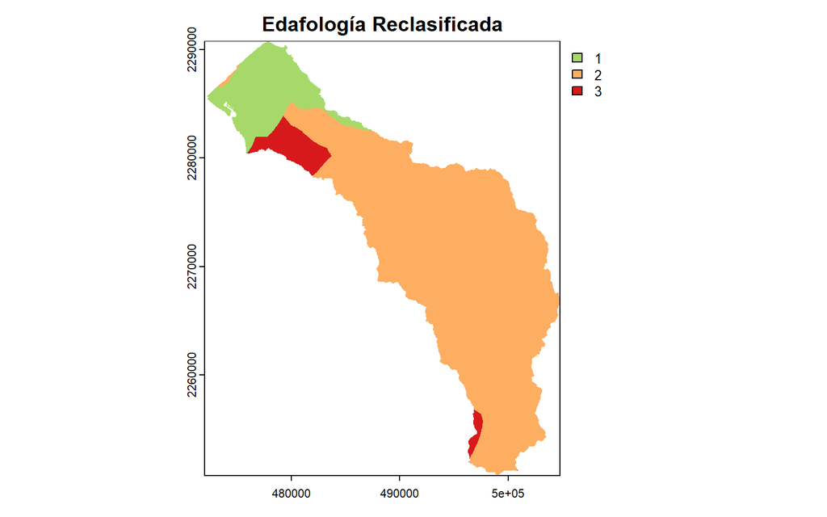

```r
plot(edafologia_raster, main = "Edafología Reclasificada", col = c("#a6d96a", "#fdae61", "#d7191c"))
```

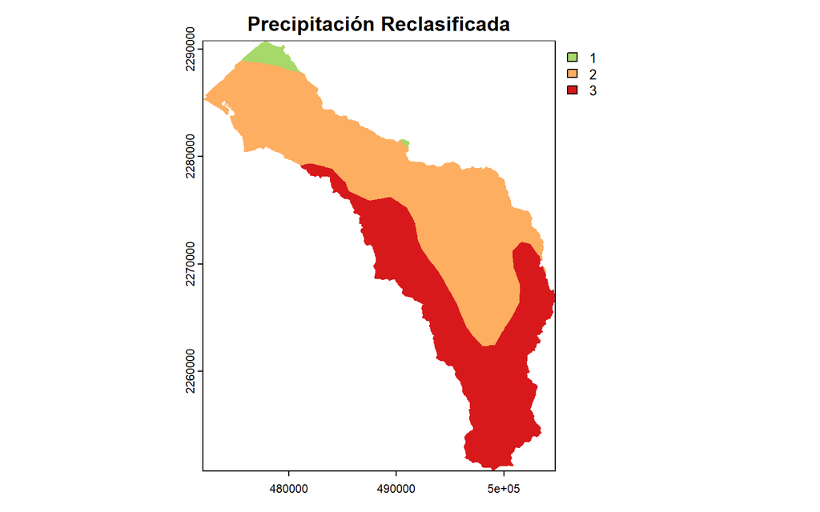

```r
plot(precipitacion_raster, main = "Precipitación Reclasificada", col = c("#a6d96a", "#fdae61", "#d7191c"))
```

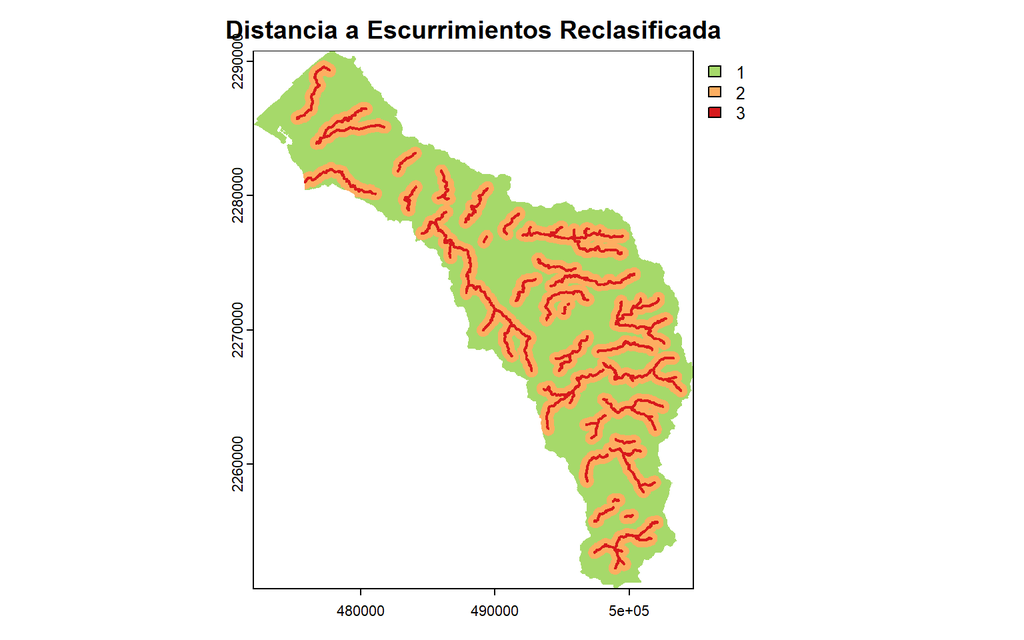

```r
plot(distancia_reclas, main = "Distancia a Escurrimientos Reclasificada", col = c("#a6d96a", "#fdae61", "#d7191c"))
```

Crear y mapear la capa de riesgo final: Se combinan todas las capas reclasificadas para generar un mapa final de riesgo de inundación.

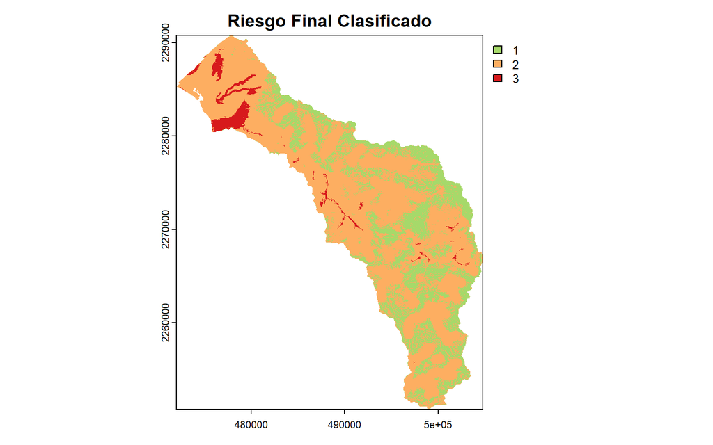

```r
# Paso 10: Crear y mapear la capa de riesgo final
capas <- c(dem_reclas,
           pendiente_reclas,
           uso_suelo_raster,
           edafologia_raster,
           precipitacion_raster,
           distancia_reclas)

riesgo_final <- mean(capas, na.rm = TRUE)
riesgo_final_clas <- classify(riesgo_final,
                              rcl = matrix(c(0, 1.5, 1,
                                             1.5, 2.25, 2,
                                             2.25, 3, 3),
                                           ncol = 3, byrow = TRUE))
# Guardar raster de riesgo
writeRaster(riesgo_final_clas, paste0(output_folder, "riesgo_final_clas_cuenca.tif"), overwrite = TRUE)

# Visualización del riesgo final
plot(riesgo_final_clas, main = "Riesgo Final Clasificado", col = c("#a6d96a", "#fdae61", "#d7191c"))
```

Realizar cálculos de área por nivel de riesgo: Se calculan las áreas correspondientes a cada nivel de riesgo y se exportan los resultados en formato tabular.

```r
# Paso 11: Realizar cálculos de área por nivel de riesgo
area_riesgo <- as.data.frame(freq(riesgo_final_clas)) %>%
  rename(riesgo = value, n_pixeles = count) %>%
  mutate(area_km2 = (n_pixeles * 225) / 1e6) %>%
  select(riesgo, n_pixeles, area_km2)

print(area_riesgo)
```

```
##   riesgo n_pixeles  area_km2
## 1      1    514336 115.72560
## 2      2   1339826 301.46085
## 3      3     64357  14.48033
```

```r
# Guardar resultados
write.csv(area_riesgo, paste0(output_folder, "area_riesgo.csv"), row.names = FALSE)
```

**Bono extra por vacaciones**: Inspeccionar el mapa de riesgo final: Se utiliza Leaflet para explorar de forma interactiva el mapa de riesgo final con una vista de satélite.

```r
# Paso 12: Inspección interactiva
# install.packages("leaflet")
library(leaflet)

# Crear paleta de colores para mapa de Leaflet
pal <- colorFactor(
  palette = c("#a6d96a", "#fdae61", "#d7191c"), # Colores para Bajo, Medio, Alto
  levels = c(1, 2, 3), # Definir niveles de riesgo
  na.color = "transparent"
)

# Crear mapa interacrivo
leaflet() %>%
  addProviderTiles(providers$Esri.WorldImagery, group = "Satellite View") %>% # Satellite base map
  addRasterImage(
    riesgo_final_clas,
    colors = pal,
    opacity = 0.8,
    group = "Flood Risk Map"
  ) %>%
  addLayersControl(
    baseGroups = c("Satellite View"), # Mapa base vista satélite
    overlayGroups = c("Capa riesgo inundación"), # Activar/desactivar mapa de riesgo
    options = layersControlOptions(collapsed = FALSE) # Mantener cotroles visibles
  ) %>%
  addLegend(
    pal = pal,
    values = c(1, 2, 3),
    title = "Niveles de riesgo",
    labFormat = function(type, cuts, p) {  # Etiquetas personalizadas
      paste(c("Bajo", "Medio", "Alto"))
    },
    opacity = 1
  )
```

[interactive chart not shown]

# ¿Que debo entregar?

En equipos de 4 estudaintes, elaborar un escrito que incluya:

- Objetivo y descripción de la práctica
- Las figuras creadas en el proceso.

Responder a las preguntas para reflexionar:

1. ¿En SIG, qué es el análisis multicriterio?
2. ¿Qué estructura de datos geográficos es cada capa de información?
3. ¿En qué proyección están los datos?
4. ¿Qué estructura de datos geográficos tiene cada variable?
5. ¿Qué es una cuenca hidrográfica, cuántas hay en México y en cuál se encuentra Bahía de Banderas?
6. ¿A qué se refiere el orden de los escurrimientos?
7. Describe las características principales de los suelos: cambisol, feozem, litosol y regosol.
8. De acuerdo con las operaciones de sobreposición de mapas, qué operaciones realizan los comandos crop y st_intersection?
9. Define qué es la reclasificación en el contexto de los SIG.
10. En el paso 8 ¿por qué crees que es necesario “rasterizar” las capas?
11. ¿Cuál es el área, en km2, de cada nivel de riesgo?
12. ¿Qué puede suceder si se cambian los valores de las matrices de reclasificación, es decir, si se modifican los rangos de valores de las variables con las que se determina el riesgo?